# R Notebook

```r
library(tidyverse)
library(scales)
library(CodeClanData)
backpack
```

| backpack_weight | body_weight | ratio | back_problems | major | year | sex | status | units |
| --- | --- | --- | --- | --- | --- | --- | --- | --- |
| 9 | 125 | 0.0720000 | 1 | Bio | 3 | Female | U | 13 |
| 8 | 195 | 0.0410256 | 0 | Philosophy | 5 | Male | U | 12 |
| 10 | 120 | 0.0833333 | 1 | GRC | 4 | Female | U | 14 |
| 6 | 155 | 0.0387097 | 0 | CSC | 6 | Male | G | 0 |
| 8 | 180 | 0.0444444 | 0 | EE | 2 | Female | U | 14 |
| 5 | 240 | 0.0208333 | 0 | History | 0 | Male | G | 0 |
| 8 | 170 | 0.0470588 | 0 | CM | 3 | Male | U | 15 |
| 4 | 185 | 0.0216216 | 1 | ARCE | 5 | Female | U | 18 |
| 5 | 130 | 0.0384615 | 0 | Bio | 4 | Female | U | 14 |
| 2 | 120 | 0.0166667 | 0 | Bio | 5 | Female | U | 8 |

[output cut: 90 more lines]

Question 1. Load in the libraries you need, and look at the backpack data. Take note of variable names and dimensions.

```r
dim(backpack)
```

```
[1] 100   9
```

```r
names(backpack)
```

```
[1] "backpack_weight" "body_weight"     "ratio"           "back_problems"
[5] "major"           "year"            "sex"             "status"
[9] "units"
```

Question 2. What is the distribution of backpack weights that students are carrying? Choose an appropriate graph to show the distribution.

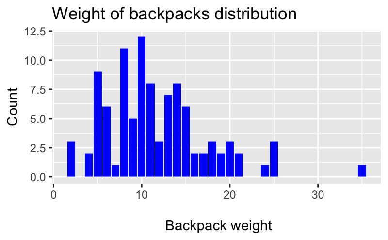

```r
ggplot(backpack) +
  aes(backpack_weight) +
  geom_bar(fill = "blue") +
   labs(
    x = "\n Backpack weight",
    y = "Count",
    title = "Weight of backpacks distribution")
```

It can be seen that most of it is around 10. There is an outlier which is around 35. Also the graph is skewed to right.

Question 3. Are there differences in backpack weight between sex?

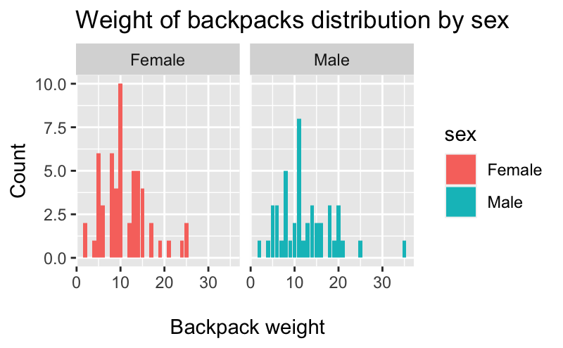

```r
ggplot(backpack) +
  aes(backpack_weight, fill = sex) +
  geom_bar() +
   labs(
    x = "\n Backpack weight",
    y = "Count",
    title = "Weight of backpacks distribution by sex") +
  facet_wrap(~sex)
```

Question 4. What is the relationship between body weight and backpack weight?

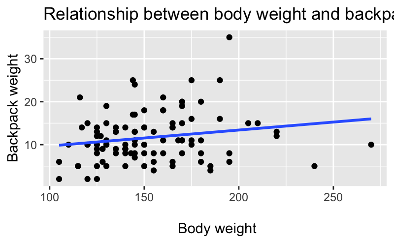

```r
ggplot(backpack) +
  aes(x = body_weight, y = backpack_weight) +
  geom_point() +
   labs(
    x = "\n Body weight",
    y = "Backpack weight",
    title = "Relationship between body weight and backpack weight") +
  geom_smooth(method = lm, se = FALSE)
```

Question 5. Is this relationship different between men and women? Choose an appropriate plot and interpret your findings.

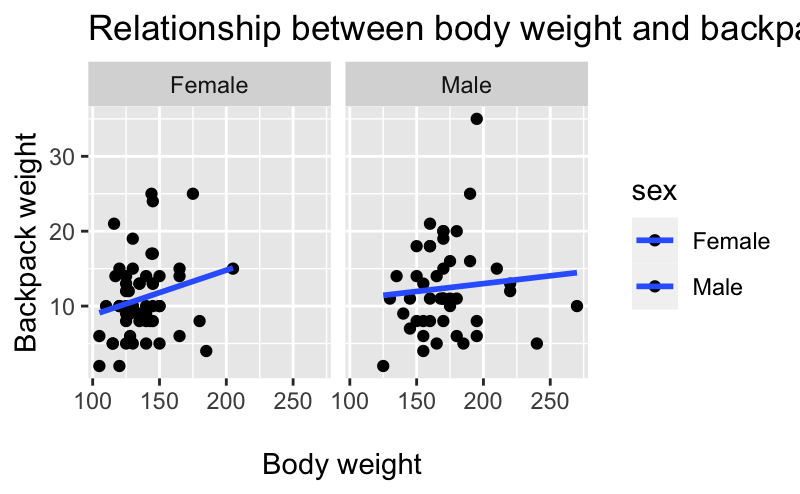

```r
ggplot(backpack) +
  aes(x = body_weight, y = backpack_weight, fill = sex) +
  geom_point() +
   labs(
    x = "\n Body weight",
    y = "Backpack weight",
    title = "Relationship between body weight and backpack weight") +
  geom_smooth(method = lm, se = FALSE) +
  facet_wrap(~sex)
```

Question 6. What proportion of students report back pain?

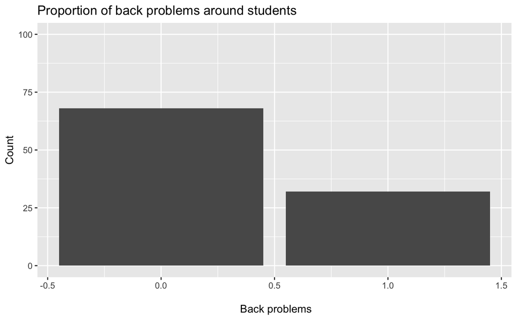

```r
backpack <-backpack %>%
  mutate(proportion = sum(back_problems))

ggplot(backpack) +
  aes(x = back_problems) +
  geom_bar() +
  ylim(0,100) +
  labs(
    x = "\n Back problems",
    y = "Count",
    title = "Proportion of back problems around students")
```

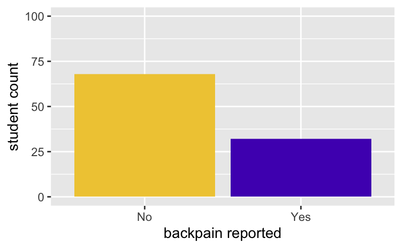

```r
backpack <- backpack %>%
  mutate(backpain_labelled = recode(back_problems,
                       "0" = "No",
                       "1" = "Yes"))

ggplot(backpack) +
  aes(x = backpain_labelled, fill = backpain_labelled) +
  geom_bar() +
ylim(0,100) +
  labs(x = "backpain reported", y = "student count") +
    scale_fill_manual(values=c('#f0ca41', '#5022bd'))+
theme(legend.position = "none")
```

Question 7. Is this proportion different between men and women?

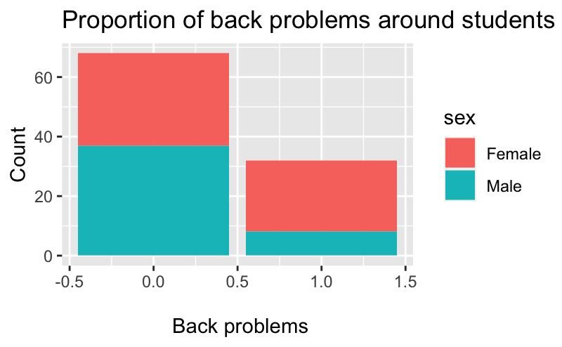

```r
backpack <-backpack %>%
  mutate(proportion = sum(back_problems))

ggplot(backpack) +
  aes(x = back_problems, fill = sex) +
  geom_bar() +
  labs(
    x = "\n Back problems",
    y = "Count",
    title = "Proportion of back problems around students")
```

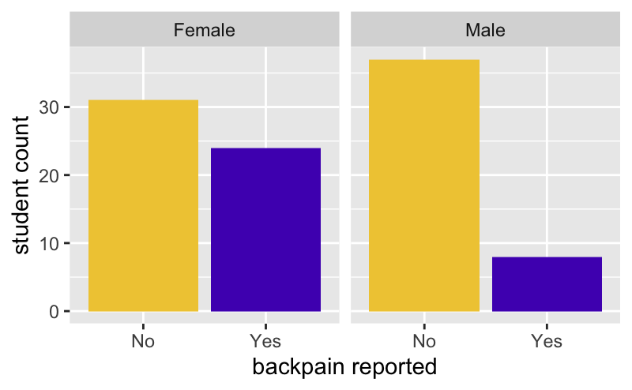

```r
ggplot(backpack) +
  aes(x = backpain_labelled, fill = backpain_labelled) +
  geom_bar() +
  labs(x = "backpain reported", y = "student count") +
  facet_wrap(~sex) +
      scale_fill_manual(values=c('#f0ca41', '#5022bd'))+
theme(legend.position = "none")
```

Question 8.

Now you’ve investigated your data separately, create plots to describe the relationship between backpack weight, body weight, gender and reported backpain.

Try both backpack_weight and body_weight as well as the ratio.

Hint: faceting would be useful here.

[figure not shown]

```r
ggplot(backpack) +
  aes(x = backpack_weight, y = body_weight) +
  geom_point() +
   labs(
    x = "\n Body weight",
    y = "Backpack weight",
    title = "Relationship between body weight and backpack weight") +
  geom_smooth(method = lm, se = FALSE) +
  facet_wrap(sex ~ back_problems)
```

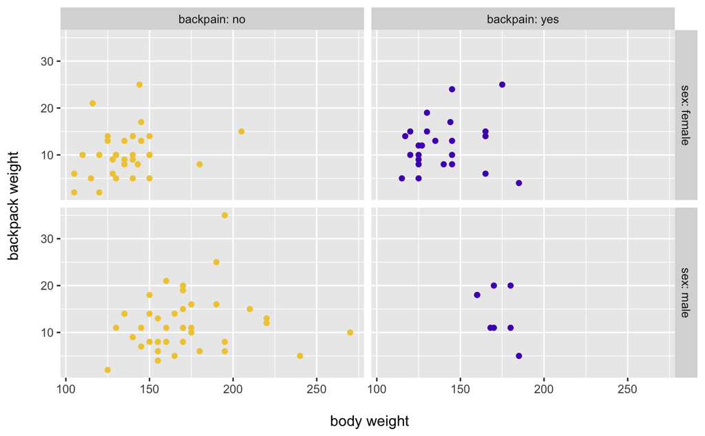

```r
pain_labels <- c("backpain: no", "backpain: yes")
names(pain_labels) <- c("No", "Yes")

sex_labels <- c("sex: female", "sex: male")
names(sex_labels) <- c("Female", "Male")


ggplot(backpack) +
  aes(x = body_weight, y = backpack_weight, color = backpain_labelled) +
  geom_point() +
  facet_grid(sex ~ backpain_labelled,
             labeller = labeller(backpain_labelled = pain_labels, sex = sex_labels)) +
  labs(x = "\n body weight", y = "backpack weight \n") +
      scale_color_manual(values=c('#f0ca41', '#5022bd'))+
theme(legend.position = "none")
```

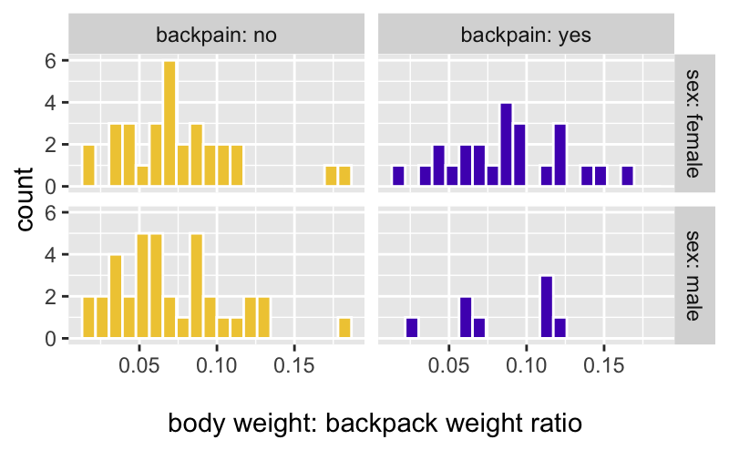

```r
ggplot(backpack) +
  geom_histogram(aes(x = ratio, fill = backpain_labelled), bins = 20, col = "white") +
  facet_grid(sex ~ backpain_labelled,
             labeller = labeller(backpain_labelled = pain_labels, sex = sex_labels)) +
  labs(x = "\n body weight: backpack weight ratio") +
      scale_fill_manual(values=c('#f0ca41', '#5022bd'))+
theme(legend.position = "none")
```

Extensions Question 1. Does reported backpain differ across the year groups? Ignore year 0 in your data.

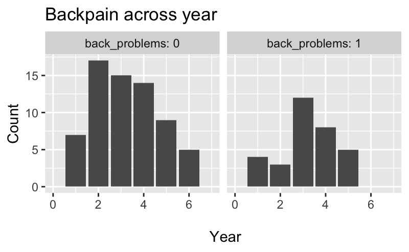

```r
ggplot(backpack) +
  aes(x = year) +
  geom_bar() +
  xlim(0, 7) +
  labs(
    x = "\n Year",
    y = "Count",
    title = "Backpain across year") +
  facet_wrap(~back_problems, labeller = "label_both")
```

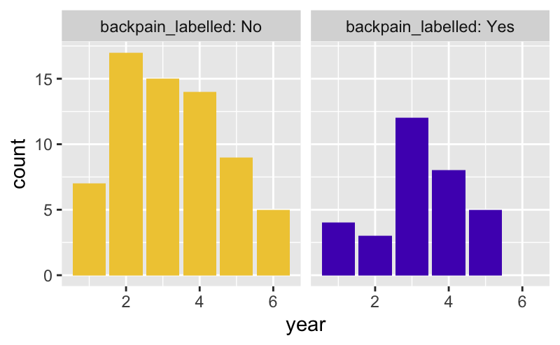

```r
subset_backpacks <- backpack %>%
  filter(year >0)

# look at the years
ggplot(subset_backpacks) +
  geom_bar(aes(x=year, fill = backpain_labelled)) +
  facet_wrap(~backpain_labelled, labeller = "label_both") +
      scale_fill_manual(values=c('#f0ca41', '#5022bd'))+
theme(legend.position = "none")
```

Question 2. Is there a difference between how heavy the bags those in different years carry?

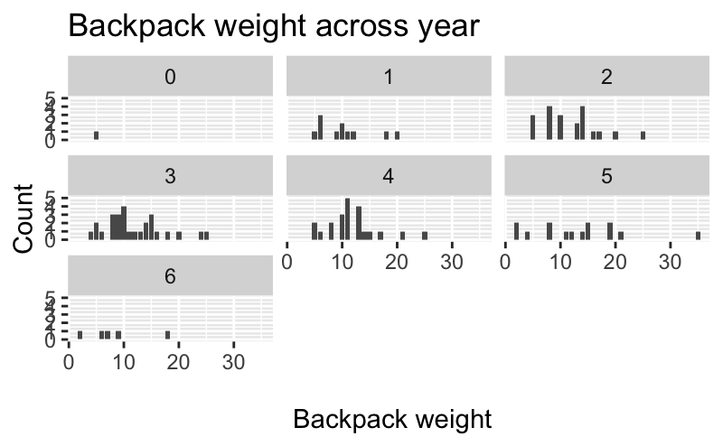

```r
ggplot(backpack) +
  aes(x = backpack_weight) +
  geom_bar()  +
  labs(
    x = "\n Backpack weight",
    y = "Count",
    title = "Backpack weight across year") +
  facet_wrap(~year, ncol = 3)
```

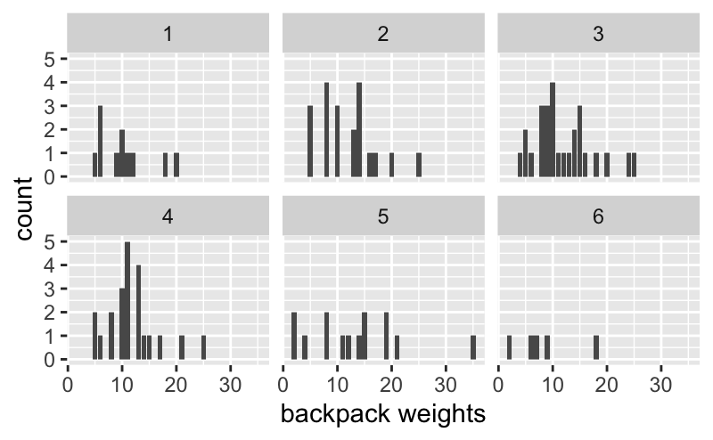

```r
ggplot(subset_backpacks)+
  geom_bar(aes(x=backpack_weight)) +
  facet_wrap(~year, ncol = 3) +
  xlab("backpack weights")
```